# Casos atendidos de violencia hacia la mujer e integrantes del grupo familiar registrados en el Perú 2020-2022

4 de junio de 2023

# **Introducción**

- **Objetivo general**
  - Analizar los índices de violencia de género que se registraron en el Perú al nivel nacional entre los año 2020-2022.
  - **Objetivos específicos**
    - Realizar una comparativa entre los casos de violencia reportados durante los años 2020-2022, con el objetivo de analizar si se observa una tendencia al aumento o disminución de estos casos a lo largo de dicho periodo de tiempo.
    - Analizar los diferentes tipos de violencia con respecto a cada año para identificar las tendencias y patrones de frecuencia en la incidencia de cada tipo de violencia para cada año.
    - Analizar la relación entre la zona geográfica y la cantidad de casos atendidos de violencia hacia la mujer en el Perú durante los años de estudio.
    - Identificar que otros integrantes del grupo familiar, aparte de la mujer, son afectados por este tipo de violencia, ver como va la tendencia entre la cantidad de reportes de violencia hacia la mujer y la cantidad de reportes de violencia hacia otros integrantes del grupo familiar.
    - Analizar la prevalencia de violencia en diferentes grupos de edad, con el fin de identificar patrones y factores de riesgo asociados a la violencia en cada grupo.
- **Relevancia**
  - La violencia hacia las mujeres y miembros del grupo familiar es un grave problema en el Perú y en todo el mundo. Analizar los casos atendidos entre 2020 y 2022 es relevante para comprender su magnitud, identificar patrones y factores de riesgo, y servir como base para políticas y programas de prevención y respuesta. Es esencial tomar medidas efectivas para prevenir y abordar la violencia en todas sus formas, ya que tiene graves consecuencias para las víctimas y la sociedad en general.
  - El análisis de datos sobre la violencia en el Perú entre 2020-2022 según sexo, rango de edad y tipo de violencia es fundamental para identificar patrones y tendencias. Este análisis es clave para el diseño de políticas y programas efectivos de prevención y respuesta.
- **Contexto**
  - El MIMP (Ministerio de la Mujer y Poblaciones Vulnerables) en Perú es la institución encargada de promover y proteger los derechos de las mujeres, así como prevenir y sancionar la violencia de género. El MIMP recopila datos sobre los casos de violencia contra la mujer, violencia familiar y violencia sexual en el país. El análisis de estos datos puede ayudar a comprender la magnitud de la violencia contra la mujer, integrantes del grupo familiar y violencia sexual en Perú, así como a identificar patrones y tendencias en diferentes regiones y entre diferentes grupos de población. Esta información es fundamental para desarrollar estrategias efectivas de prevención, atención y protección de las víctimas de violencia de género.
- **Planificación**

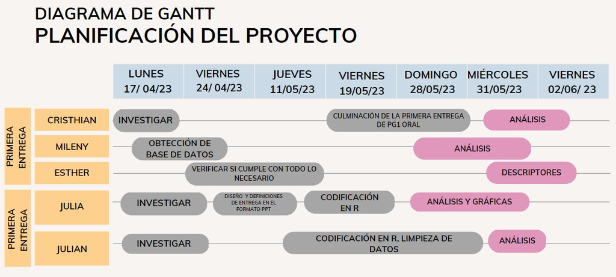

- **Datos**
  - Obtención de datos: Pasos durante el proceso
  - Método de recolección de datos Para llegar a obtener los datos, optamos por utilizar una base de datos ya existente, debía ser confiable y que sea un tema relevante.
  - Definir la cantidad de observaciones Aquí establecemos algunas restricciones con respecto la cantidad de observaciones que requerimos para nuestra investigación.
- **Población, Muestra y Muestreo**

  Población: Población peruana. Muestra: 419674 personas aproximadamente. Muestreo: Probabilístico (Muestreo Aleatorio Simple)

# **Datos**

- **Recolección de datos**
- **Variables y analisis descriptivo**

| Variables | Tipo | Clase | Descripción |
| --- | --- | --- | --- |
| Periodo | Categórica | Nominal | Periodo de la información remitida |
| Departamento | Categórica | Nominal | Entidad subnacional desde donde se recepcionó el caso por parte de la línea de intervención |
| Provincia | Categórica | Nominal | Entidad local desde donde se recepcionó el caso por parte de la linea de intervención |
| Distrito | Categórica | Nominal | Subdivisión de las provincias de menor categoría desde donde se recepcionó el caso por parte de la línea de intervención |
| Nombre centro de atención | Categórica | Nominal | Lugar que brinda cuidados para la salud |
| Año | Numérica | Discreta | Año del reporte de caso de violencia |
| Casos atendidos-total | Numérica | Discreta | Margen total de casos atendidos ante pedido de ayuda |
| Casos atendidos-violencia psicológica | Numérica | Discreta | Margen total de casos atendidos por violencia psicológica |
| Casos atendidos-violencia física | Numérica | Discreta | Margen total de casos atendidos por violencia física |
| Casos atendidos-violencia sexual | Numérica | Discreta | Margen total de casos atendidos por violencia sexual |
| Casos atendidos-hombres | Numérica | Discreta | Margen total de hombres que fueron atendidos ante el pedido de ayuda |
| Casos atendidos-mujeres | Numérica | Discreta | Margen total de mujeres que fueron atendidas ante el pedido de ayuda |
| Casos atendidos- 0-5 años | Numérica | Discreta | Margen total de casos atendidos por edad |
| Casos atendidos- 6-11 años | Numérica | Discreta | Margen total de casos atendidos por edad |
| Casos atendidos- 12-17 años | Numérica | Discreta | Margen total de casos atendidos por edad |
| Casos atendidos- 18-29 años | Numérica | Discreta | Margen total de casos atendidos por edad |
| Casos atendidos- 30-59 años | Numérica | Discreta | Margen total de casos atendidos por edad |
| Casos atendidos- 60-más años | Numérica | Discreta | Margen total de casos atendidos por edad |

- **Limpieza de datos**

Identificamos que nuestra base de datos contaba con palabras mal escritas o tipificadas, lo pasamos todo a un solo formato.

La variable departamento contaba con un dato Lima que se encontraba subdividida( Lima provincia, Lima metropolitana), este dato tanbiem lo modificamos y lo colocamos en uno solo como Lima

- Obtención de base de datos por fuentes secundarios ([Base de datos](https://www.datosabiertos.gob.pe/dataset/mimp-n%C3%BAmero-de-casos-atendidos-por-violencia-contra-la-mujer-integrantes-del-grupo-familiar))

# **DESCRIPTORES**

### **BIVARIADO**

#### **Casos atendidos por año**

```
##    Año CasosAtendidos
## 1 2020         113963
## 2 2021         163155
## 3 2022         142556
```

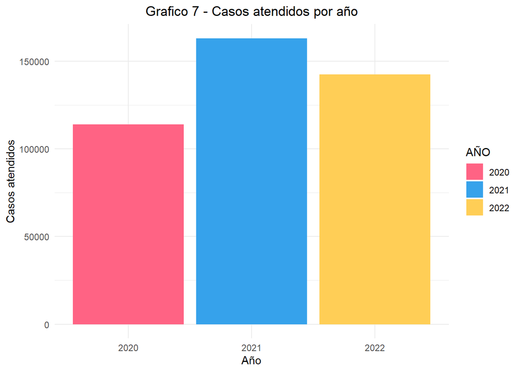

#### **Casos atendidos por grupo de edades**

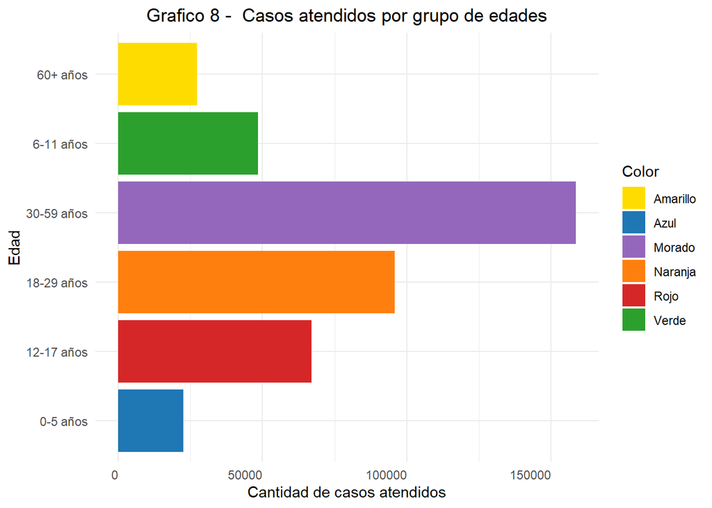

Total de casos atendidos de 30-59 años

```
## [1] 158458
```

Total casos atendidos de 0 a 5 años

```
## [1] 22668
```

#### **Tipos de violencia con respecto a cada año**

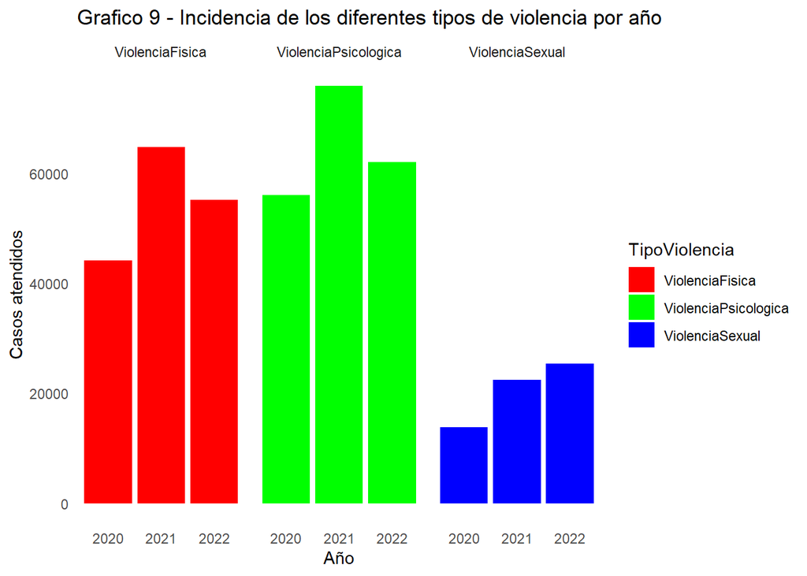

```
## # A tibble: 3 x 2
##   TipoViolencia        Cantidad
##   <chr>                   <dbl>
## 1 ViolenciaFisica        164065
## 2 ViolenciaPsicologica   193907
## 3 ViolenciaSexual         61702
```

[output not shown]

```
## # A tibble: 9 x 3
## # Groups:   Año [3]
##     Año TipoViolencia        Cantidad
##   <dbl> <chr>                   <dbl>
## 1  2020 ViolenciaFisica         44125
## 2  2020 ViolenciaPsicologica    55995
## 3  2020 ViolenciaSexual         13843
## 4  2021 ViolenciaFisica         64805
## 5  2021 ViolenciaPsicologica    75894
## 6  2021 ViolenciaSexual         22456
## 7  2022 ViolenciaFisica         55135
## 8  2022 ViolenciaPsicologica    62018
## 9  2022 ViolenciaSexual         25403
```

#### **Casos atendidos por ubicación**

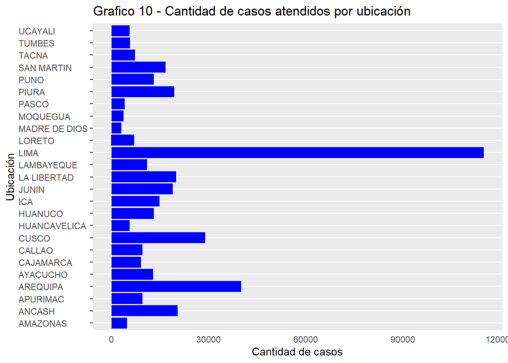

```
## # A tibble: 25 x 2
##    ubicacion    total_casos
##    <chr>              <dbl>
##  1 AMAZONAS            4764
##  2 ANCASH             20477
##  3 APURIMAC            9582
##  4 AREQUIPA           40116
##  5 AYACUCHO           12884
##  6 CAJAMARCA           9166
##  7 CALLAO              9579
##  8 CUSCO              28943
##  9 HUANCAVELICA        5570
## 10 HUANUCO            13043
## # i 15 more rows
```

```
## [1] "Departamento con la mayor cantidad de casos: LIMA"
```

```
## [1] "Departamento con la menor cantidad de casos: MADRE DE DIOS"
```

```
## [1] "Cantidad de casos para el departamento con la mayor cantidad: 114965"
```

```
## [1] "Cantidad de casos para el departamento con la menor cantidad: 3090"
```

#### **Casos atendidos por región**

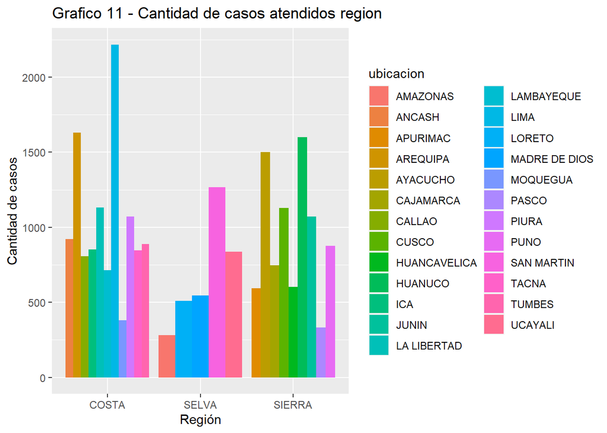

```
##    grupo cantidad_casos
## 1  COSTA         267075
## 2  SELVA          37229
## 3 SIERRA         115370
```

#### **Casos de violencia hacia hombres y mujeres registrados en cada año**

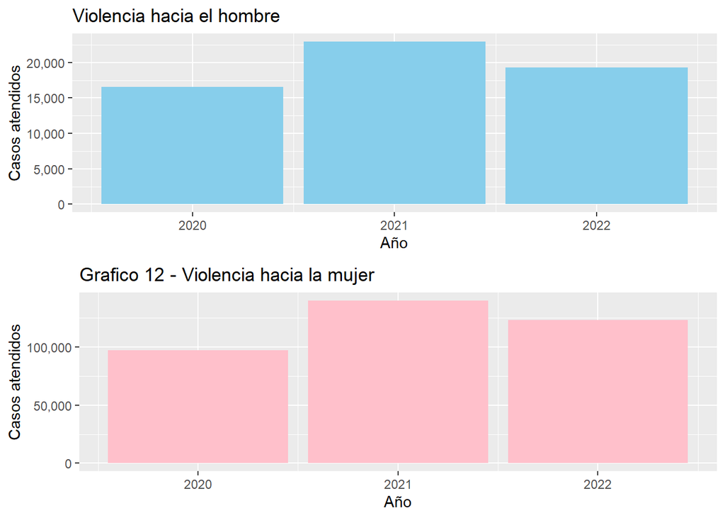

```
## Para el año 2020 para la mujer se registraron: 97394
```

```
## Para el año 2021 para la mujer se registraron: 140191
```

```
## Para el año 2022 para la mujer se registraron: 123280
```

```
## Para el año 2020 para el hombre se registraron: 16569
```

```
## Para el año 2021 para el hombre se registraron: 22964
```

```
## Para el año 2022 para el hombre se registraron: 19276
```

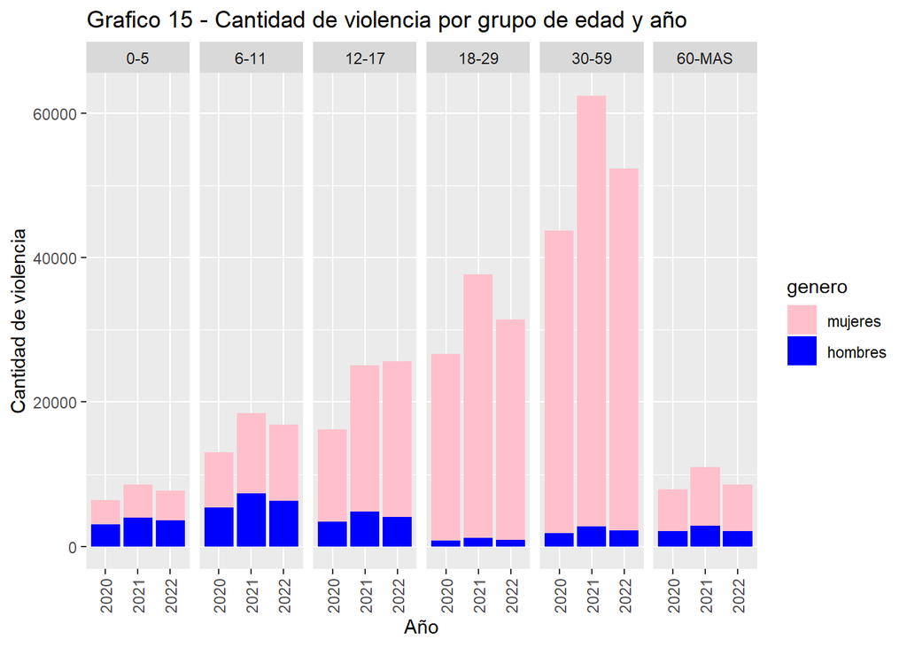

```
##     genero grupo_edad  año cantidad
## 1  mujeres        0-5 2020     3371
## 2  hombres        0-5 2020     3067
## 3  mujeres       6-11 2020     7639
## 4  hombres       6-11 2020     5406
## 5  mujeres      12-17 2020    12790
## 6  hombres      12-17 2020     3388
## 7  mujeres      18-29 2020    25849
## 8  hombres      18-29 2020      788
## 9  mujeres      30-59 2020    41900
## 10 hombres      30-59 2020     1819
## 11 mujeres     60-MAS 2020     5845
## 12 hombres     60-MAS 2020     2101
## 13 mujeres        0-5 2021     4559
## 14 hombres        0-5 2021     3993
```

[output cut: 22 more lines]

# **Análisis Probabilístico**

## Probabilidad Condicional

- TRABAJAMOS PARA 2 EVENTOS:
- **Eventos dependientes**
- **Relación entre la variable año y género** TRABAJAMOS PARA 2 EVENTOS: PARA A SE USARA LA VARIABLE AÑO PARA B SE USARA LA VARIABLE CASOS TOTALES MUJERES A: Seleccionar un caso atendido de violencia en el año 2021 B: Seleccionar una caso de violencia hacia la mujer

```r
# Crear una tabla vacía de 4 filas y 5 columnas
tabla <- matrix(nrow = 3, ncol = 4)

# Ingresar los valores manualmente
tabla[1, ] <- c(16569, 22964, 19276, 58809)
tabla[2, ] <- c(97394, 140191, 123280, 360865)
tabla[3, ] <- c(113963, 163155, 142556, 419674)

# Convertir la matriz en un objeto de tipo "data.frame"
df <- as.data.frame(tabla)

# Nombrar las filas y columnas de la tabla
row.names(df) <- c("Hombre", "Mujer", "Total")
colnames(df) <- c("Año-2020", "Año-2021", "Año-2022", "Total")

# Imprimir la tabla en la consola
df
```

|  | Año-2020 | Año-2021 | Año-2022 | Total |
| --- | --- | --- | --- | --- |
| Hombre | 16569 | 22964 | 19276 | 58809 |
| Mujer | 97394 | 140191 | 123280 | 360865 |
| Total | 113963 | 163155 | 142556 | 419674 |

```r
CASOS20<-filter(DF,DF$AÑO==2020)
sumC20<-sum(CASOS20$`CASOS ATENDIDOS-TOTAL--`)


CASOS21<-filter(DF,DF$AÑO==2021)
sumC21<-sum(CASOS21$`CASOS ATENDIDOS-TOTAL--`)

CASOS22<-filter(DF,DF$AÑO==2022)
sumC22<-sum(CASOS22$`CASOS ATENDIDOS-TOTAL--`)
```

```r
evento_A <- sumC21
total_eventos <- sum(DF$`CASOS ATENDIDOS-TOTAL--`)
P_evento_A <- evento_A / total_eventos
P_evento_A
```

```
## [1] 0.388766
```

$$P(A) = 0.388766$$

```r
evento_B <- sum(DF$`CASOS ATENDIDOS - MUJERES - TOTAL`)
total_eventos <- sum(DF$`CASOS ATENDIDOS-TOTAL--`)
P_evento_B <- evento_B / total_eventos
P_evento_B
```

```
## [1] 0.8598698
```

$$P(B) = 0.8598698$$

```r
evento_A_interseccion_B <- sum(filter(DF,DF$AÑO == 2021)$`CASOS ATENDIDOS - MUJERES - TOTAL`)
evento_A_interseccion_B
```

```
## [1] 140191
```

```r
total_eventos <- sumC20+sumC21+sumC22
P_evento_A_interseccion_B <- evento_A_interseccion_B/total_eventos
P_evento_A_interseccion_B
```

```
## [1] 0.3340474
```

$$P(A ∩ B) = 0.3340474$$
*Verificación de independencia*

*P(A n B) = P(A).P(B)*

```r
P_evento_A_interseccion_B
```

```
## [1] 0.3340474
```

```r
P_evento_A * P_evento_B
```

```
## [1] 0.3342882
```

```r
error<-abs(P_evento_A_interseccion_B-(P_evento_A*P_evento_B))
error
```

```
## [1] 0.0002408008
```

$$P(A ∩ B) = 0.3340474$$
$$P(A ∩ B) = P(A).P(B)$$
$$0.3340474 = 0.3342882$$
$$P(A∩B)-(P(A)*P(B)) < 0.01 =
Independientes$$
$$0.0002408008 <
0.01 = Independientes$$
Se comprueba que son eventos independientes, esto implica que la probabilidad de seleccionar un caso de violencia hacia el hombre no es afectada por el año en el que ocurrió. *Usando Bayes, se verifica entonces P(B|A) = P(A|B)P(B)/ P(A) Donde P(A) puede ser caracterizada por la probabilidad total*

```r
# Crear una tabla vacía de 4 filas y 5 columnas
tabla <- matrix(nrow = 3, ncol = 3)

# Ingresar los valores manualmente
tabla[1, ] <- c(35845, 22964, 58809)
tabla[2, ] <- c(220674, 140191, 360865)
tabla[3, ] <- c(256519, 163155, 419674)

# Convertir la matriz en un objeto de tipo "data.frame"
df <- as.data.frame(tabla)

# Nombrar las filas y columnas de la tabla
row.names(df) <- c("Hombre", "Mujer", "Total")
colnames(df) <- c(" 2020 y 2022 ","2021", "Total")

# Imprimir la tabla en la consola
df
```

|  | 2020 y 2022 | 2021 | Total |
| --- | --- | --- | --- |
| Hombre | 35845 | 22964 | 58809 |
| Mujer | 220674 | 140191 | 360865 |
| Total | 256519 | 163155 | 419674 |

- *Probabilidad Condicional*
  - **Teorema de Bayes** *P(B|A) = P(A|B)P(B)/ P(A)* P(B)= La probabilidad de seleccionar una caso de violencia hacia la mujer

```r
P_evento_B
```

```
## [1] 0.8598698
```

$$P(B|A) = P(A ∩ B))/ P(A)$$

```r
P_A_B <- abs(P_evento_A_interseccion_B/(P_evento_B))
P_A_B
```

```
## [1] 0.388486
```

```r
P_B_A <- abs(P_evento_A_interseccion_B/(P_evento_A))
P_B_A
```

```
## [1] 0.8592504
```

$$P(B|A) = 0.8592504$$
$$P(B|A) = P(A|B)*P(B)/ P(A)$$

```r
P__B_A <- ((0.388486*0.8598698)/0.388766)
P__B_A
```

```
## [1] 0.8592505
```

$$P(A) = P(A|B)*P(B)/P(B|A)$$

```r
P_A = ((0.388486*0.8598698)/ 0.8592504)
P_A
```

```
## [1] 0.388766
```

$$P(A) = 0.388766$$
Conclusión: La independencia entre los eventos sugiere que la ocurrencia de casos de violencia hacia el hombre no está relacionada con el año específico en este caso el año 2021. Esto implica que la probabilidad de seleccionar un caso de violencia hacia el hombre no se ve afectada por el año en el que ocurrió.

## **Variable dependiente**

- **Relación entre la variable Casos de violencia y rango de edad**

TRABAJAMOS PARA 2 EVENTOS: PARA A SE USARA LA VARIABLE CASOS ATENDIDOS - MUJERES. PARA B SE USARA LA VARIABLE CASOS ATENDIDOS - 30_59 AÑOS. A: Seleccionar un caso de violencia infringido hacia la mujer. B: Seleccionar un caso de violencia infringido en el rango de edad de 30 a 59 años.

```
## [1] 360865
```

```
## [1] 0.8598698
```

$$P(A) = 0.8598698$$

```r
evento__B <-sum(DF$`CASOS ATENDIDOS - 30_59 - TOTAL`)
evento__B
```

```
## [1] 158458
```

```r
total__eventos <- sum(DF$`CASOS ATENDIDOS-TOTAL--`)
P__evento_B <- evento__B / total__eventos
P__evento_B
```

```
## [1] 0.377574
```

$$P(B) = 0.377574$$

```r
evento__A_interseccion_B <- sum(DF$`CASOS ATENDIDOS - 30_59 - MUJERES`)
total__eventos <- sum(DF$`CASOS ATENDIDOS-TOTAL--`)
P__evento_A_interseccion_B <- evento__A_interseccion_B/total__eventos
P__evento_A_interseccion_B
```

```
## [1] 0.3614544
```

$$P(A ∩ B) = 0.3614544$$
+ *Verificación de dependencia*

```r
P__evento_A_interseccion_B
```

```
## [1] 0.3614544
```

```r
P__evento_A * P__evento_B
```

```
## [1] 0.3246645
```

```r
error<-abs(P__evento_A_interseccion_B-(P__evento_A*P__evento_B))
error
```

```
## [1] 0.03678987
```

$$P(A∩B)-(P(A)*P(B)) < 0.01 =
Independientes$$
$$0.03678987 >
0.01$$
Los eventos son dependientes entre si, ya que en la verificación de dependencia se observa que el resultado es mayor al limite establecido.

*P(A n B) = P(A).P(B)*

$$P(A ∩ B) = 0.3614544$$
$$P(A ∩ B) = P(A).P(B)$$
$$0.3614544 ≠ 0.3246644799$$

*Usando Bayes, se verifica entonces P(B|A) = P(A|B)P(B)/ P(A) Donde P(A) puede ser caracterizada por la probabilidad total*

*Probabilidad Condicional* **Teorema de Bayes** *P(B|A) = P(A|B)P(B)/ P(A)* P(B)= La probabilidad de seleccionar un caso atendido en el rango de edad de 30 a 59 años.

```r
P__evento_B
```

```
## [1] 0.377574
```

$$P(B|A) = P(A ∩ B))/ P(A)$$

```r
P__A_B <- abs(P__evento_A_interseccion_B/(P__evento_B))
P__A_B
```

```
## [1] 0.9573073
```

```r
P__B_A <- abs(P__evento_A_interseccion_B/(P__evento_A))
P__B_A
```

```
## [1] 0.4203594
```

$$P(B|A) = 0.4203594$$
$$P(A|B) = 0.9573073$$
$$P(B|A) = P(A|B)*P(B)/ P(A)$$

```r
P__B_A <- ((0.9573073*0.377574)/0.8598698)
P__B_A
```

```
## [1] 0.4203594
```

$$P(A) = P(A|B)*P(B)/P(B|A)$$

```r
P__A = ((0.9573073*0.377574)/0.4203594)
P__A
```

```
## [1] 0.8598698
```

$$P(A) = 0.8598698$$
Conclusión: Los eventos son dependientes, factores culturales y de género: Las normas culturales arraigadas y las actitudes de género pueden influir en la violencia hacia la mujer. En algunos contextos, se pueden esperar roles específicos para las mujeres en el hogar y en la sociedad, lo que puede contribuir a la perpetuación de la violencia, gran parte de las mujeres en este rango de edad conviven, se encuentran casadas o tienen una pareja sentimental. Muchas mujeres en este grupo de edad pueden encontrarse en relaciones de pareja estables o casadas, lo que puede aumentar la probabilidad de estar expuestas a la violencia doméstica. Además, algunas mujeres pueden experimentar violencia en el lugar de trabajo o en otros entornos sociales.

## **PROBABILIDAD EMPIRICA**

### ELEGIMOS LA VARIABLE: RANGO DE EDAD

- **Experimento**: Seleccione una persona de 30_59 años que haya sufrido algún caso de violencia
- **Eventos atomicos**:
- {P1,P2,P3,P4,P5,P6}
- **Identificamos los eventos**:
- Seleccione una persona de 0_5 años que haya sufrido algún caso de violencia
- Seleccione una persona de 6_11 años que haya sufrido algún caso de violencia
- Seleccione una persona de 12_17 años que haya sufrido algún caso de violencia
- Seleccione una persona de 18_29 años que haya sufrido algún caso de violencia
- Seleccione una persona de 30_59 años que haya sufrido algún caso de violencia
- Seleccione una persona de 60_mas años que haya sufrido algún caso de violencia

### Probablidad de caso de violencia del rango de 0-5 años

```
## [1] 0.05401335
```

### Probablidad de caso de violencia del rango de 6-11 años

```
## [1] 0.1154301
```

### Probabilidad de caso de violencia del rango de 12-17 años

```
## [1] 0.1594428
```

### Probabilidad de caso de violencia del rango de 18-29 años

```
## [1] 0.2281747
```

### Probabilidad de caso de violencia del rango de 30-59 años

```
## [1] 0.377574
```

### Probabilidad de caso de violencia del rango de 60-mas años

```
## [1] 0.06536502
```

### Comprobando que la suma de la probabilidad sea 1

```r
P1+P2+P3+P4+P5+P6
```

```
## [1] 1
```

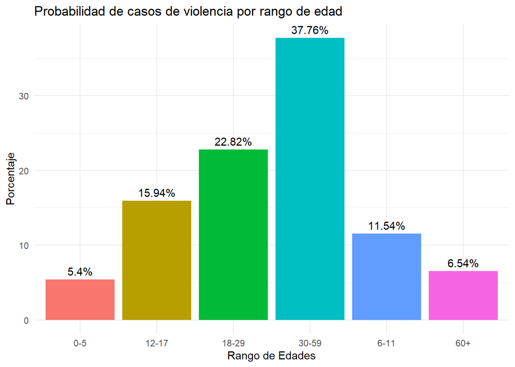

### ELEGIMOS LA VARIABLE: TIPO DE VIOLENCIA

- **Experimento**: Seleccione una persona que haya sufrido violencia sexual
- **Eventos atomicos**:
- {v1,v2,v3}
- **Identificamos los eventos**:
- Seleccione una persona que haya sufrido violencia Psicologica
- Seleccione una persona que haya sufrido violencia Fisica
- Seleccione una persona que haya sufrido violencia Sexual

### Probabilidad de caso por violencia psicologica

```
## [1] 0.462042
```

### Probabilidad de caso por violencia fisica

```
## [1] 0.3909344
```

### Probabilidad de caso por violencia sexual

```
## [1] 0.1470236
```

### Comprobando que la suma de la probabilidad sea 1

```
## [1] 1
```

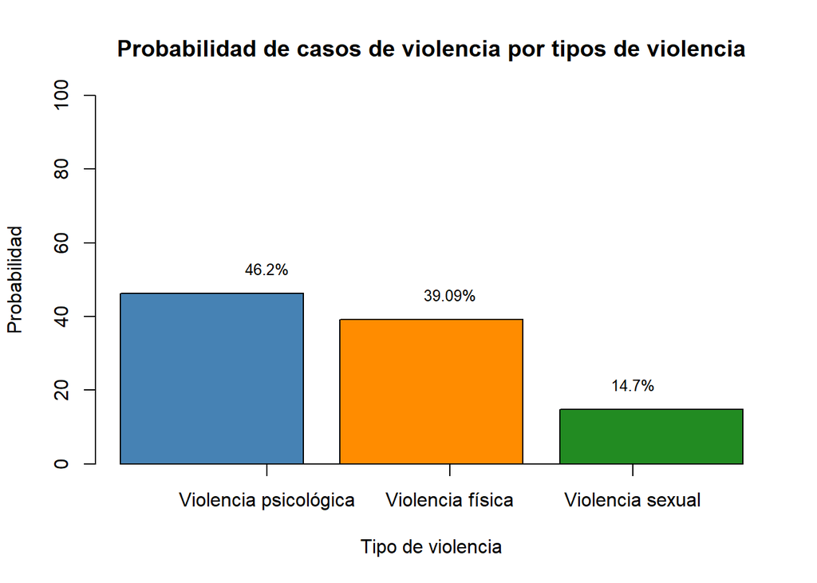

## **VARIABLE CONTINUA**

### Variable continua- Indice de tipos de violencia

| AÑO | FECHA ENVIO | DEPARTAMENTO | PROVINCIA | DISTRITO | NOMBRE CENTRO ATENCION | CASOS ATENDIDOS-TOTAL-- | CASOS ATENDIDOS - HOMBRES - TOTAL | CASOS ATENDIDOS - MUJERES - TOTAL | CASOS ATENDIDOS - VIOLENCIA PSICOLOGICA | CASOS ATENDIDOS - VIOLENCIA FISICA | CASOS ATENDIDOS - VIOLENCIA SEXUAL | CASOS ATENDIDOS - 0_5 - TOTAL | CASOS ATENDIDOS - 0_5 - HOMBRES | CASOS ATENDIDOS - 0_5 - MUJERES | CASOS ATENDIDOS - 6_11 - TOTAL | CASOS ATENDIDOS - 6_11 - HOMBRES | CASOS ATENDIDOS - 6_11 - MUJERES | CASOS ATENDIDOS - 12_17 - TOTAL | CASOS ATENDIDOS - 12_17 - HOMBRES | CASOS ATENDIDOS - 12_17 - MUJERES | CASOS ATENDIDOS - 18_29 - TOTAL | CASOS ATENDIDOS - 18_29 - HOMBRES | CASOS ATENDIDOS - 18_29 - MUJERES | CASOS ATENDIDOS - 30_59 - TOTAL | CASOS ATENDIDOS - 30_59 - HOMBRES | CASOS ATENDIDOS - 30_59 - MUJERES | CASOS ATENDIDOS - 60_MAS - TOTAL | CASOS ATENDIDOS - 60_MAS - HOMBRES | CASOS ATENDIDOS - 60_MAS - MUJERES | … |
| --- | --- | --- | --- | --- | --- | --- | --- | --- | --- | --- | --- | --- | --- | --- | --- | --- | --- | --- | --- | --- | --- | --- | --- | --- | --- | --- | --- | --- | --- | --- |
| 2020 | 15/01/2021 | APURIMAC | ABANCAY | ABANCAY | CEM ABANCAY | 175 | 14 | 161 | 101 | 61 | 13 | 3 | 2 | 1 | 11 | 7 | 4 | 13 | 2 | 11 | 39 | 0 | 39 | 95 | 1 | 94 | 14 | 2 | 12 | … |
| 2020 | 15/01/2021 | HUANCAVELICA | ACOBAMBA | ACOBAMBA | CEM ACOBAMBA | 146 | 6 | 140 | 55 | 74 | 17 | 4 | 2 | 2 | 5 | 0 | 5 | 17 | 1 | 16 | 52 | 0 | 52 | 61 | 1 | 60 | 7 | 2 | 5 | … |
| 2020 | 15/01/2021 | HUANUCO | AMBO | AMBO | CEM AMBO | 181 | 12 | 169 | 68 | 84 | 29 | 11 | 3 | 8 | 14 | 4 | 10 | 34 | 2 | 32 | 60 | 0 | 60 | 53 | 1 | 52 | 9 | 2 | 7 | … |
| 2020 | 15/01/2021 | APURIMAC | ANDAHUAYLAS | ANDAHUAYLAS | CEM ANDAHUAYLAS | 266 | 22 | 244 | 152 | 92 | 22 | 2 | 0 | 2 | 22 | 9 | 13 | 30 | 5 | 25 | 71 | 2 | 69 | 123 | 2 | 121 | 18 | 4 | 14 | … |
| 2020 | 15/01/2021 | APURIMAC | ANTABAMBA | ANTABAMBA | CEM ANTABAMBA | 108 | 14 | 94 | 47 | 58 | 3 | 3 | 2 | 1 | 5 | 2 | 3 | 16 | 2 | 14 | 17 | 2 | 15 | 54 | 5 | 49 | 13 | 1 | 12 | … |
| 2020 | 15/01/2021 | PIURA | AYABACA | AYABACA | CEM AYABACA | 159 | 12 | 147 | 66 | 62 | 31 | 2 | 2 | 0 | 15 | 3 | 12 | 35 | 2 | 33 | 40 | 1 | 39 | 61 | 1 | 60 | 6 | 3 | 3 | … |
| 2020 | 15/01/2021 | AYACUCHO | HUAMANGA | AYACUCHO | CEM HUAMANGA | 357 | 28 | 329 | 215 | 104 | 38 | 9 | 4 | 5 | 30 | 10 | 20 | 31 | 3 | 28 | 98 | 1 | 97 | 165 | 3 | 162 | 24 | 7 | 17 | … |
| 2020 | 15/01/2021 | AMAZONAS | BAGUA | BAGUA | CEM BAGUA | 101 | 21 | 80 | 46 | 34 | 21 | 13 | 7 | 6 | 19 | 7 | 12 | 22 | 4 | 18 | 20 | 0 | 20 | 23 | 1 | 22 | 4 | 2 | 2 | … |
| 2020 | 15/01/2021 | CAJAMARCA | CAJAMARCA | CAJAMARCA | CEM CAJAMARCA | 132 | 19 | 113 | 40 | 52 | 40 | 9 | 5 | 4 | 22 | 8 | 14 | 31 | 4 | 27 | 23 | 0 | 23 | 41 | 1 | 40 | 6 | 1 | 5 | … |
| 2020 | 15/01/2021 | CALLAO | CALLAO | CALLAO | CEM CALLAO | 683 | 145 | 538 | 293 | 259 | 131 | 79 | 34 | 45 | 136 | 71 | 65 | 101 | 22 | 79 | 131 | 4 | 127 | 187 | 7 | 180 | 49 | 7 | 42 | … |

[output cut: 1266 more lines]

### Comprobando que el indice por cada observacion sea 1

### Identificacion graficamente

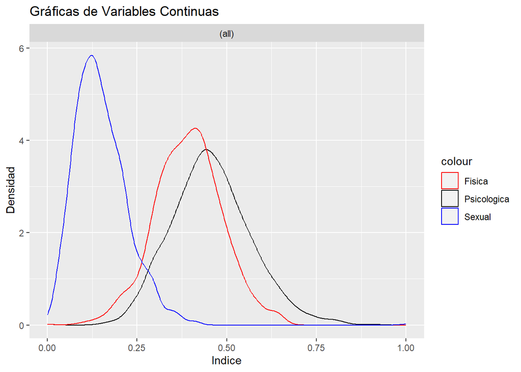

### Validar las propiedad por media y mediana

```
##                   media   mediana
## I_Psicologico 0.4566915 0.4504505
## I_Fisica      0.3932705 0.3943662
## I_Sexual      0.1500380 0.1386139
```

### Validar las propiedades por varianza y variacion estandas al cuadrado

```
##                  varianza desviacion...desviacion
## I_Psicologico 0.012460422             0.012460422
## I_Fisica      0.009031901             0.009031901
## I_Sexual      0.005689470             0.005689470
```

Cual es la probabilidad de que el idice en violencia sexual menor a 0.5 en el perido 2020-2022

```
## [1] 0.9968652
```

### Identificacion graficamente

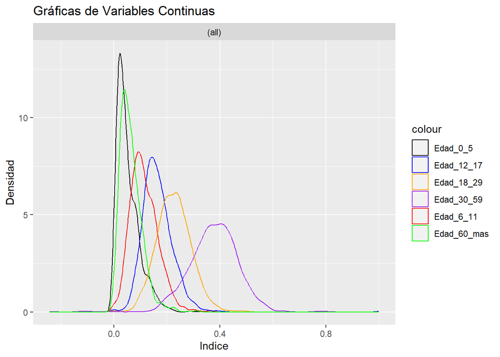

### Validar las propiedad por media y mediana

```
##                  media    mediana
## Edad_0_5    0.05308256 0.04178273
## Edad_6_11   0.11424307 0.10752688
## Edad_12_17  0.16483776 0.15827338
## Edad_18_29  0.22658312 0.22580645
## Edad_30_59  0.37686370 0.38116592
## Edad_60_mas 0.06438979 0.05671642
```

### Validar las propiedades por varianza y variacion estandas al cuadrado

```
##                varianza desviacion...desviacion
## Edad_0_5    0.001836234             0.001836234
## Edad_6_11   0.002698417             0.002698417
## Edad_12_17  0.003484972             0.003484972
## Edad_18_29  0.004145759             0.004145759
## Edad_30_59  0.008456572             0.008456572
## Edad_60_mas 0.001704200             0.001704200
```

cual es la probabilidad de que el indice en el rango de edad 30-59 años sea mayor a 0.5 en el periodo 2020-2022

```
## [1] 0.06991359
```

**Variables aleatorias distcretas** Variable = VIOLENCIA SEXUAL

**Distribución binomial**

```
##    Min. 1st Qu.  Median    Mean 3rd Qu.    Max.
##    0.00   19.00   36.00   48.36   62.00  309.00
```

Situación: En el Perú, se ha evidenciado que la cantidad de casos atendidos ham sido muy pocas, teniendo un máximo de 309 en un distrito del Perú, hasta un lamentable 0 de casos atendidos, claro esto depende de cuantos casos se denuncian. Para nuestra variable **`CASOS ATENDIDOS DE VIOLENCIA SEXUAL`** denotaremos una encuesta a partir de 100 centros de atención y consideraremos como un éxito que en una provincia se atiendan 70 o más denuncias de casos de violencia sexual y un fracaso si esta cantidad es menos. ¿Cuál es la probabilidad de que 20 o menos centros de atención registren 70 o más casos atendidos de violencia sexual?

Probabilidad de éxito (p)= Centro de atención que tenga 70 o mas casos atendidos (CASOS_ATENTIDOS_VIOLENCIA_SEXUAL >= 70) Probabilidad de fracaso (q)= Centro de atención que tenga menos de 70 casos atendidos (CASOS_ATENTIDOS_VIOLENCIA_SEXUAL < 70)

| Var1 | Var2 | Cumple_Condicion |
| --- | --- | --- |
| 13 | CEM ABANCAY | C < C_prom |
| 17 | CEM ACOBAMBA | C < C_prom |
| 29 | CEM AMBO | C < C_prom |
| 22 | CEM ANDAHUAYLAS | C < C_prom |
| 3 | CEM ANTABAMBA | C < C_prom |
| 31 | CEM AYABACA | C < C_prom |
| 38 | CEM HUAMANGA | C < C_prom |
| 21 | CEM BAGUA | C < C_prom |
| 40 | CEM CAJAMARCA | C < C_prom |
| 131 | CEM CALLAO | C >= C_prom |

[output cut: 1266 more lines]

```
## [1] 0.211
```

```
## [1] 0.789
```

$$p = 0.211$$
$$q = 0.789$$

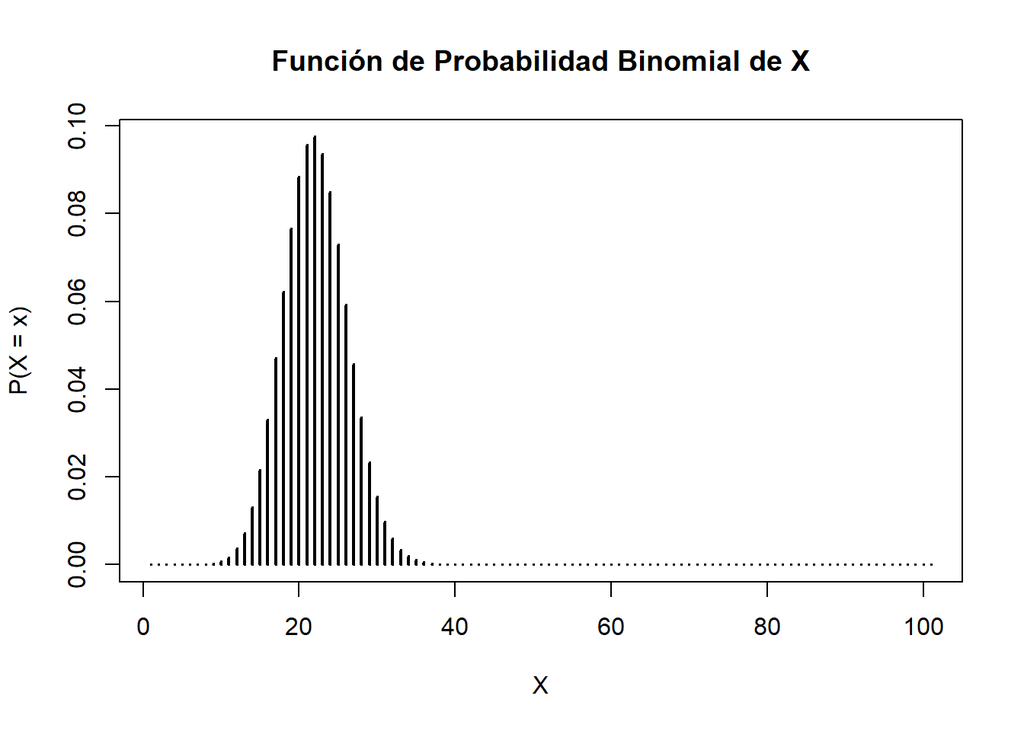

¿Cuál es la probabilidad de que 20 o menos centros de atención registren 70 o más casos atendidos de violencia sexual?

```
## [1] 0.4508218
```

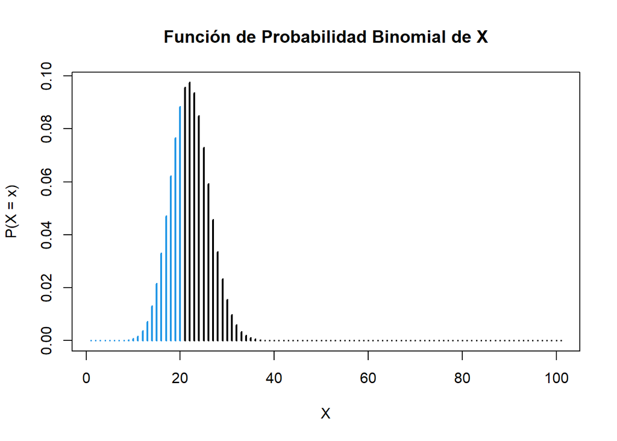

```
## [1] 21.1
```

```
## [1] 16.6479
```

**Distribución Geométrica** La distribución geométrica es un tipo de modelo probabilístico discreto que se emplea para estimar la probabilidad de lograr un número específico de intentos necesarios para obtener un resultado exitoso por primera vez. Se basa en “N” experimentos independientes, y el proceso se considera finalizado una vez que se alcanza el primer éxito.

$$P(X=x) = ((1-p)^(n-1))*p$$

```
## [1] 52.44044
```

$$Esperanza = 52.44044$$

```
## [1] 1877.407
```

$$Varianza = 1877.407$$
Determinamos los parámetros de la distribución geométrica. Parámetro p

```
## [1] 0.01906925
```

$$p = 0.01906925$$

**Situación** En este modelo, nuestra variable se denomina **`VG2`**. En el caso de la distribución geométrica, consideramos un éxito cuando se registra por primera vez un caso de violencia en el rango de edad de 12 a 17 años, y un fracaso cuando se registra otro tipo de caso de violencia en otro rango de edad. Supongamos que nuestro equipo de trabajo registra 345 observaciones hasta obtener el primer caso de violencia entre el rango de 12 a 17 años. **`¿Cuál es la probabilidad de que se necesiten 20 o menos observaciones para obtener por primera vez dicho caso?`**

Definimos nuestra variable aleatoria discreta:

X: número de observaciones necesarias para obtener el primer registro de violencia entre el rango de 12 a 17 años en una provincia de Lima.

Conociendo la probabilidad de éxito:

$$X∼G(p)$$
$$X∼G(0.01906925)$$
Represetando gráficamente la función de probabilidad geométrica de la variable discreta X.

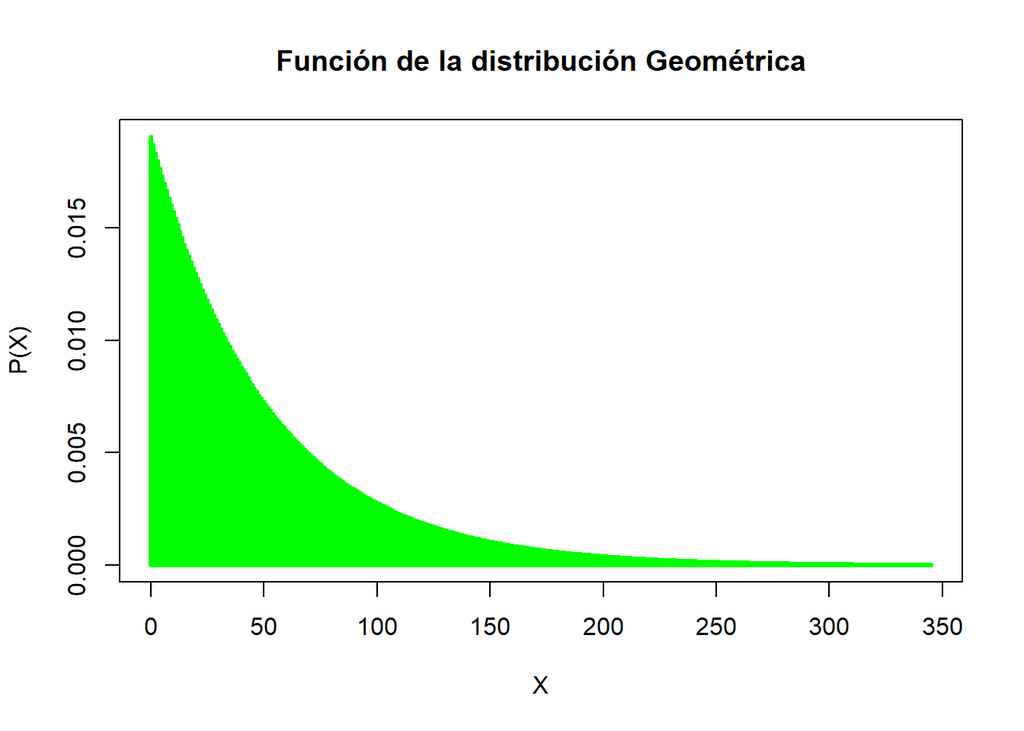

La situación nos pide la probabilidad de que se necesiten 20 o menos observaciones para obtener por primera vez un registro de violencia entre el rango de 12 a 17 años:
$$P(X≤20)=1-P(X>20)$$

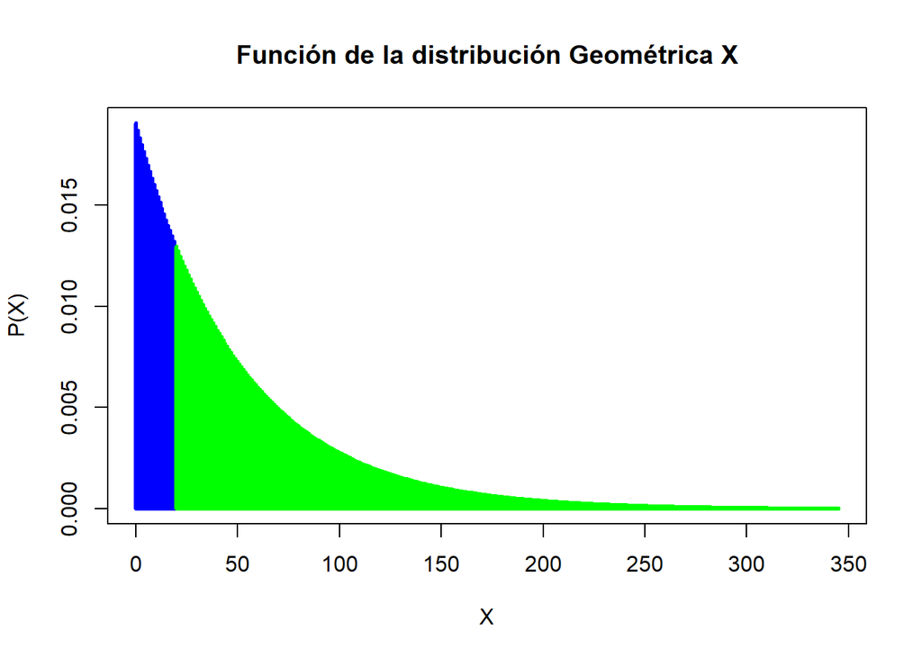

```
## La probabilidad de que sea necesrio regisrar 20 o menos observaciones por primera de un caso de violencia entre el rango de 12 a 17 años: 0.3326
```